# Instrumentation, Exercices

Auteur·rice

Joseph Moerschell, Marc Nicollerat

## 1 CAPTEUR OPTIQUE INCRÉMENTAL DE POSITION – OPTISCHER INKREMENTALSENSOR

Ein optischer Inkrementalgeber mit einer Scheibe mit 512 Strichen ist an der Welle eines Antriebs befestigt. Der Zähler der Winkelposition zählt alle Flanken der beiden Ausgangssignale in Quadratur. Sein Wert wird periodisch mit einer Periode von $T_s=1ms$ ausgelesen.

1. Welches ist die einfachste Art die Drehgeschwindigkeit $\dot{x}(k \cdot T_s)$ anhand der Messungen der Winkelpositionen $x(k \cdot Ts)$ und $x((k-1) \cdot Ts)$ zu bestimmen?
2. Welches ist der Absolutfehler der so gemessenen Drehgeschwindigkeit? Wie muss die Anzahl Striche der Scheibe des Aufnehmers verändert werden um den gleichen absoluten Fehler bei einer Ausleseperiode von Ts=0.5 ms zu erhalten?
3. Die obere Grenze der Frequenz der Ausgangssignale des Aufnehmers ist 100 kHz. Welches sind daher der Messbereich der Drehgeschwindigkeit und ihr kleinster und grösster relativer Fehler?

Un codeur optique incrémental avec un disque gravé de 512 stries est monté sur l’arbre d’un entraînement. Le compteur de la position angulaire compte tous les flancs des deux signaux de sortie en quadrature1 . Sa valeur est lue périodiquement avec une période $T_s=1ms$.

1 .Quelle est la manière la plus simple de déterminer la vitesse de rotation $\dot{x}(k \cdot T_s)$ à partir des mesures de position angulaire $x(k \cdot Ts)$ et $x((k-1) \cdot Ts)$

2. Quelle est l’erreur absolue sur la vitesse lorsqu’elle est mesurée de cette façon ? Combien de stries devrait-on graver sur le disque du capteur si l’on voulait obtenir la même erreur absolue avec une période de lecture de Ts=0.5 ms ?
3. On suppose que la fréquence des signaux de sortie du capteur est limitée à 100 kHz. Quelle est la plage de mesure de la vitesse angulaire ? Quelle erreur relative obtient-on à la vitesse maximale ? Idem pour la vitesse minimale ?

**Note**

Les signaux A et B provenant des cellules photoélectriques sont périodiques : une période correspond à la distance entre deux traits, que l’on assimile au 360o d’un cercle. Si l’on prend en compte tous les flancs montants et descendants des signaux A et B on obtient 4 transitions sur une période, donc une tous les 90°, soit chaque fois que l’on passe d’un quadrant au suivant. On peut donc incrémenter le compteur chaque fois que l’on a parcouru un quart de la distance qui sépare deux traits.

## 2 CHOIX D’UN CAPTEUR OPTIQUE DE POSITION ANGULAIRE – AUSWAHL EINES OPTISCHEN DREHWINKELSENSORS

Endlosmaterial (Papier, Folie, Blech usw.) soll in Teilstücke abgelängt werden. Die herzustellenden Teilstücke haben verschiedene Längen. Die Einzellängen können bis zu 6000mm betragen. Die Messrolle hat einen Umfang von 500mm. Die Messgenauigkeit für ein beliebiges Teilstück muss +/- 0.1[mm] betragen. Für die Messung des Vorschubes (Messung der Teilstücke) soll ein Drehgeber eingesetzt werden.

Le matériau arrivant en continu (papier, feuille, tôle, etc.) doit être coupé en feuilles de différentes longueurs. Une feuille peut atteindre une longueur de 6000 [mm] au maximum Pour mesurer la longueur des feuilles on utilise un codeur rotatif placé sur l’axe d’un rouleau de mesure MR dont le périmètre vaut 500 [mm]. Pour une feuille de longueur quelconque la précision de la mesure doit être de +/- 0.1 [mm].

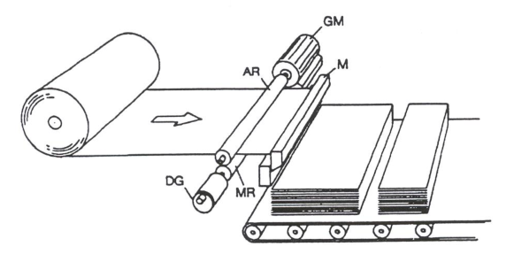

| AR | Antriebsrolle | Rouleau d’entraînement |
| --- | --- | --- |
| MR | Messrolle | Rouleau de mesure |
| GM | Gleichstrommotor | Moteur courant-continu |
| M | Messer | Couteau |
| DG | Drehgeber (Winkelcodierer) | Capteur rotatif (codeur d’angle) |

1. Schauen Sie die nächsten Seiten an: welche der beschriebenen Drehgeber kommen für diese Aufgabe in Frage? (Welcher Drehgeber würden Sie einsetzen?). Begründen Sie Ihre Antwort.
2. Wie gross ist der maximale absolute Messfehler der Teilstücke, falls der von Ihnen gewählte Drehgeber eingesetzt wird und falls man nur die Messgenauigkeit des Drehgebers (unter Standardbedingungen) berücksichtigt.
3. Wie gross darf die maximale Bandgeschwindigkeit sein, damit der von Ihnen gewählte Drehgeber fehlerfrei funktioniert?
4. Welche wichtigen Anforderungen fehlen in der Aufgabenstellung und welche wichtigen Daten fehlen in den beigelegten Beschreibungen, damit das Problem 1 besser gelöst werden könnte?
1. Examinez les pages suivantes : quels codeurs peuvent être utilisés ? (à votre avis quel est le codeur le plus approprié ?)

   Expliquez votre réponse.
2. Quelle est l’erreur de mesurage absolu maximal de ces pièces, si l’on utilise l’encodeur choisi par vous et que l’on ne tient compte que de la précision des mesures de l’encodeur (aux conditions standard).
3. Quelle est la vitesse maximale de bande pour laquelle votre encodeur fonctionne encore correctement ?
4. Quelles conditions importantes manquent dans les données du problème et quelles données manquent dans la description annexée pour qu’on puisse mieux résoudre le problème 1.

## 3 Capteurs

### 3.1 MAXON Codeur HEDS 5540, 500 impulsions, 3 canaux

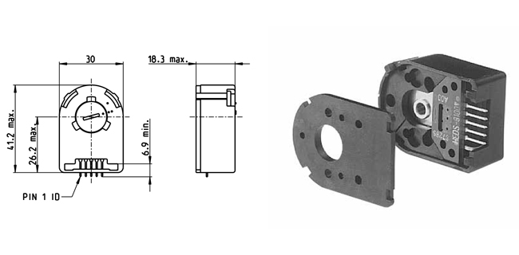

| Encoder resolution | 500 |
| --- | --- |
| Channels | 3 |
| Line driver | No |
| Max mechanical speed | 12000 rpm |

### 3.2 MAXON Codeur ENX 10 EASY, 1 - 1024 impulsions

[figure not shown]

| Encoder Resolution | 1024 |
| --- | --- |
| Channels | 3 |
| Line driver | RS422 |
| Max electrical speed | 90000 rpm |
| Max mechanical speed | 30000 rpm |

[figure not shown]

| Encoder resolution | 32768 |
| --- | --- |
| Channels | 3 |
| Line driver | RS422 |
| Max electrical speed | 5000 rpm |
| Max mechanical speed | 40000 rpm |

### 3.4 Kuebler 8.KIS40.1342.2500 - Rotary Encoder

[figure not shown]

| Encoder Output Type | Push-Pull |
| --- | --- |
| Revolution Speed | 4500 min-1 |
| Pulse frequency | 250kHz |
| Encoder Resolution | 2500 PPR |
| Channels | 2 |

### 3.5 PHM510-1312-002 - Absolute Multiturn Encoder

[figure not shown]

| Encoder Output Type | Push-Pull |
| --- | --- |
| Revolution Speed | 6000 min-1 |
| Encoder Resolution | 8192 per turn |

## 4 Solutions

### 4.1 CAPTEUR OPTIQUE INCRÉMENTAL DE POSITION – OPTISCHER INKREMENTALSENSOR

1. Calcul de la vitesse
   $$\dot{x}(k\cdot T_s)=\frac{x(k\cdot T_s)-x((k-1)\cdot T_s)}{T_s}$$
2. Erreur absolue sur la vitesse

- Comment doit-on modifier le nombre de stries de la roue du capteur si l’on veut obtenir la même erreur absolue avec une période de lecture $T_s=0.5ms$ ?

  Si la période d’échantillonnage diminue de moitié il faut doubler le nombre de stries pour obtenir la même erreur absolue !

  Wenn die Abtastperiode um die Hälfte sinkt, muss man die Anzahl Striche verdoppeln, um denselben absoluten Fehler zu erreichen.
3. La plage de mesure de vitesse

La fréquence maximum du signal est de 100kHz, en divisant par le nombre de stries on obtient le nombre de tour/s :
$$v_{max}=\frac{f_{max}}{512 } = 195.3 \left[\frac{tour}{s}\right]$$

Erreur relative maximale de la vitesse (à $v_{min}=0$) :
$$e_{rv} = \frac{E_{av}}{v_{min}}\cdot 100[\%] \to \infty[\%]$$

### 4.2 CHOIX D’UN CAPTEUR OPTIQUE DE POSITION ANGULAIRE – AUSWAHL EINES OPTISCHEN DREHWINKELSENSORS

1. Vorgeschlagener Winkelkodierer: / Encodeur proposé :
   - Benötigte Umdrehungszahl: / Nombre de tours nécessaire : $\infty$ -> Inkrementale Winkelkodierer / Codeurs incrémental
   - Benötigte Auflösung: / Résolution nécessaire au niveau du capteur :
     $$R_{min} = \frac{0.1[mm]}{500[mm]} = \frac{1}{5000} \longrightarrow 5'000$$
     [Striche pro Umdrehung / transitions par tour]

Les codeurs possibles ont une résolution supérieure à $5000/4=1250 [raies/t]$.

**Important**

Par la suite, on suppose que le codeur a 2500 raies par tour (Kuebler). $R_b=2500$

2. Maximaler absoluter Fehler: / Erreur absolue maximale sur la position :

$$E_a = \frac{500[mm]}{2'500 \cdot 4} = 0.05[mm]$$

  La vitesse est limitée par la vitesse mécanique.
4. Fehlende Angaben in der Problemstellung:

   Conditions manquant dans les données du problème :
   - Mechanische Anforderungen / Conditions mécaniques (accouplement…).
   - Umbebungsbedingungen / Conditions d’environnement (température, humidité, rayonnement électromagnétiques…).
   - Versorgungsspannung / Tension d’alimentation.
   - Spezifikation des Ausgangssignals und Verarbeitung des Ausgangssignals. Spécification du signal de sortie et traitement du signal de sortie.
   - Bandgeschwindigkeit / vitesse de la bande souhaitée.
   - …
5. Fehlende Angaben in den Datenblättern:

   Conditions manquantes dans la description annexée:
   - Umgebungsbedingungen / Conditions d’environnement (température, humidité, rayonnement EM…).
   - Spezifikation des Ausgangssignals und Verarbeitung des Ausgangssignals. Spécification du signal de sortie et traitement du signal de sortie.
   - Preise / Prix.